# 10_Combine_Figures

Adam Dziorny

2022-10-20

## Overview

The purpose of this markdown is to generate combined (CHOP + URMC) figures for publication.

## Initialize

First we load the necessary packages:

```r
suppressPackageStartupMessages({

  # Data frame manipulation
  require(dplyr)

  # Graphics and output
  require(ggplot2)
  require(cowplot)

  # Tables
  require(knitr)
  require(kableExtra)

  # Error grid point allocation
  require(ptinpoly)

})
```

Ensure the environmental variables are specified:

```r
if (Sys.getenv('PICU_LAB_DATA_PATH') == '' |
    Sys.getenv('PICU_LAB_IMG_PATH') == '' |
    Sys.getenv('PICU_LAB_IN_FILE') == '' |
    Sys.getenv('PICU_LAB_SITE_NAME') == '' |
    Sys.getenv('PICU_LAB_RUN_DATE') == '' |
    Sys.getenv('PICU_LAB_IMG_SAVE_DATE') == '')
  stop('Missing necessary environmental variables - see README.md')
```

Specify the run date of the source data files:

```r
run.date <- Sys.getenv('PICU_LAB_RUN_DATE')

cat(sprintf('Run Date: %s\n', run.date))
```

```
## Run Date: 2022-12-22
```

Now specify the save date for the output images (which may be identical to the run date):

```r
img.save.date <- Sys.getenv('PICU_LAB_IMG_SAVE_DATE')

cat(sprintf('Image Save Date: %s\n', img.save.date))
```

```
## Image Save Date: 2022-12-22
```

#### Image Parameters

```r
ext <- '.tiff'

dpi <- 600

compress <- 'lzw'
```

### Variable Extraction Functions

Here we define several helper functions for extracting variabes out of RData files. These are useful to pull specific variables from rData files into the `.GlobalEnv` without loading the entire rData file.

```r
#'
#' @title Make File Name
#'
#' @description Helper function to make the file name from site, file, run.date
#'
.makeFileName <- function (site, file, run.date) {

  return(
    file.path(
      Sys.getenv('PICU_LAB_DATA_PATH'),
      paste0(site, '_', file, '_', run.date, '.rData')
    )
  )
}

#'
#' @title List Vars
#'
#' @description Lists the variables within an rData file
#'
#' @param site The name of the site for extraction (e.g. `URMC` or `CHOP`)
#' @param file The rData file name (without the `<site>` or `<date>` parts)
#' @param run.date The run.date string
#' @param attach If TRUE, attaches to the file [Default]
#' @param detach If TRUE, detaches the file after extraction [Default]
#'
listVars <- function (site, file, run.date, attach = T, detach = T) {

  file.name <- .makeFileName(site,file,run.date)

  if (attach)
    attach(file.name)

  pos <- which(search() == paste0('file:', file.name))


  print(ls(pos = pos))

  if (detach)
    detach(pos = pos)
}

#'
#' @title Extract Var
#'
#' @description Extracts a variable from an rData file to the Global Env
#'
#' @param old.var The variable name in the rData file (not character string)
#' @param new.var.name The character string of the new variable name to be
#'     stored in the Global Env
#' @param site The name of the site for extraction (e.g. `URMC` or `CHOP`)
#' @param file The rData file name (without the `<site>` or `<date>` parts)
#' @param run.date The run.date string
#' @param attach If TRUE, attaches to the file [Default]
#' @param detach If TRUE, detaches the file after extraction [Default]
#'
extractVar <- function (old.var, new.var.name, site, file, run.date,
                        attach = T, detach = T) {

  file.name <- .makeFileName(site,file,run.date)

  if (attach)
    attach(file.name)

  pos <- which(search() == paste0('file:', file.name))

  assign(
    x = new.var.name,
    value = old.var,
    envir = .GlobalEnv
  )

  if (detach)
    detach(pos = pos)
}
```

To demonstrate how these work, we display the variables within the `thresholds_CBC-BG` file from `CHOP`, extract the `p` plot variable into the variable name `My_Var_Name`, display the plot, and remove it.

```r
listVars('CHOP', 'thresholds_CBC-BG', run.date, detach = F)
```

```
## [1] "p"
```

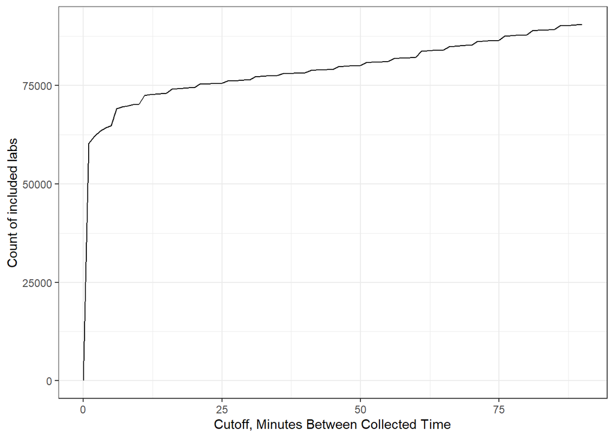

```r
extractVar(p, 'My_Var_Name', 'CHOP', 'thresholds_CBC-BG', run.date, attach = F)

print(My_Var_Name)
```

```r
rm(My_Var_Name)
```

## Original Manuscript Figures

### Figure 1

Figure 1 is a three-panel (vertical) figure of Hgb distributions. These data are stored in the `analytic` files:

```r
listVars('CHOP', 'pri_cbc_bg_analytic', run.date)
```

The variable of interest is `paired.res`:

```r
extractVar(paired.res, 'CHOP.dist.BG', 'CHOP', 'pri_cbc_bg_analytic', run.date)

extractVar(paired.res, 'URMC.dist.BG', 'URMC', 'pri_cbc_bg_analytic', run.date)

extractVar(paired.res, 'CHOP.dist.POC', 'CHOP', 'pri_cbc_istat_analytic', run.date)
```

Now create the figure:

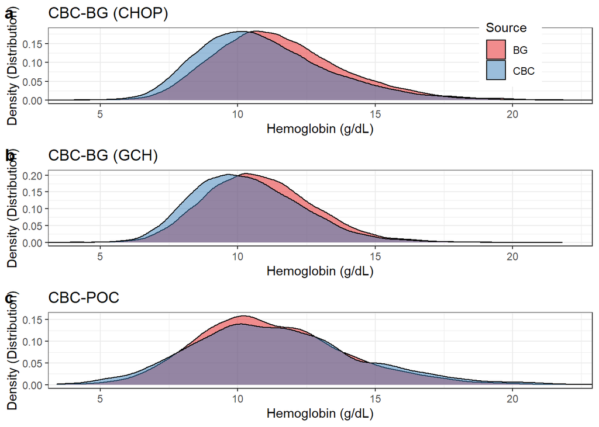

```r
Figure_1 <-
  cowplot::plot_grid(
    CHOP.dist.BG$density.p +
      coord_cartesian(xlim = c(4,22)) +
      ggtitle('CBC-BG (CHOP)') +
      theme(
        legend.position = c(0.85, 0.7)
      ),
    URMC.dist.BG$density.p +
      coord_cartesian(xlim = c(4,22)) +
      ggtitle('CBC-BG (GCH)') +
      theme(
        legend.position = 'none'
      ),
    CHOP.dist.POC$density.p +
      coord_cartesian(xlim = c(4,22)) +
      ggtitle('CBC-POC') +
      theme(
        legend.position = 'none'
      ),
    labels = tolower(LETTERS[1:3]),
    ncol = 1, nrow = 3)

print(Figure_1)
```

```r
# Export
ggplot2::ggsave(
  filename = file.path(
    Sys.getenv('PICU_LAB_IMG_PATH'),
    paste0(img.save.date, '_Figure-1', ext)
  ),
  plot = Figure_1,
  width = 6, height = 7, units = 'in', dpi = dpi, compression = compress)
```

### Figure 2

Figure 2 is a six-panel figure, consisting of the three Bland-Altman figures across the top (CHOP BG, URMC BG, CHOP POC) followed by the three Error Grids across the bottom (same order - CHOP BG, URMC BG, CHOP POC). The B-A figures are stored in `pri_cbc_bg_analytic` and the error grids are stored in `pri_cbc_bg_clinical`.

**ACD 2023-01-14** At the request of the editorial office, we are modifying Figure 2 to be a three-panel figure of the Error Grids. The three B-A plots will be placed in the Supplemental Digital Content. We will create both figures in this section, since the code was already here.

First we view the variables to determine the BA plots (set to EVAL=FALSE since we don’t need to do this each time):

```r
listVars('CHOP', 'pri_cbc_bg_analytic', run.date)
```

The variable of interest is `ba.all`. Here we load them from the respective files:

```r
extractVar(ba.all, 'p.CHOP.BA.BG', 'CHOP', 'pri_cbc_bg_analytic', run.date)

extractVar(ba.all, 'p.URMC.BA.BG', 'URMC', 'pri_cbc_bg_analytic', run.date)

extractVar(ba.all, 'p.CHOP.BA.POC', 'CHOP', 'pri_cbc_istat_analytic', run.date)
```

Now we view the variables to determine the Error_Grid plots (again set to EVAL=FALSE since we don’t need to do this each time):

```r
listVars('CHOP', 'pri_cbc_bg_clinical', run.date)

listVars('CHOP', 'pri_cbc_istat_clinical', run.date)
```

The variable of interest is `error.grid.cbc.bg`. Here we load them from the respective files:

```r
extractVar(error.grid.cbc.bg, 'p.CHOP.EG.BG', 'CHOP', 'pri_cbc_bg_clinical', run.date)

extractVar(error.grid.cbc.bg, 'p.URMC.EG.BG', 'URMC', 'pri_cbc_bg_clinical', run.date)

extractVar(error.grid, 'p.CHOP.EG.POC', 'CHOP', 'pri_cbc_istat_clinical', run.date)
```

Generate the figure:

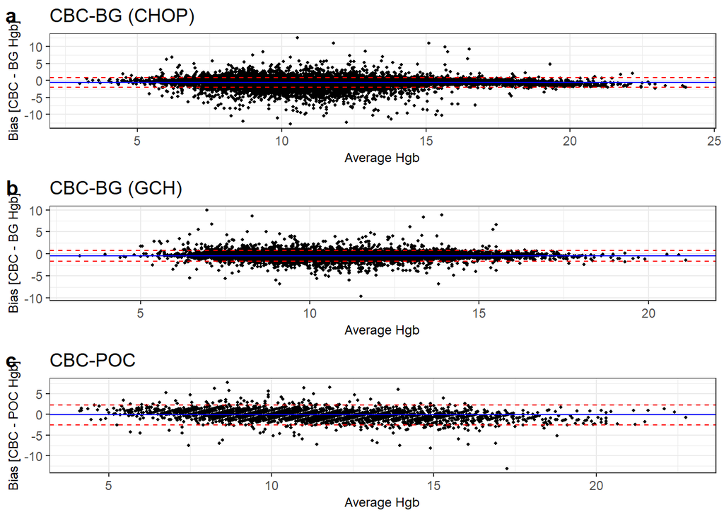

```r
Supp_BA_Plots <-
  cowplot::plot_grid(
    p.CHOP.BA.BG$plot +
      ggtitle('CBC-BG (CHOP)') +
      xlab('Average Hgb') +
      ylab('Bias [CBC - BG Hgb]') +
      theme(
        title = element_text(size = 11),
        axis.title = element_text(size = 9)
      ),
    p.URMC.BA.BG$plot +
      ggtitle('CBC-BG (GCH)') +
      xlab('Average Hgb') +
      ylab('Bias [CBC - BG Hgb]') +
      theme(
        title = element_text(size = 11),
        axis.title = element_text(size = 9)
      ),
    p.CHOP.BA.POC$plot +
      ggtitle('CBC-POC') +
      xlab('Average Hgb') +
      ylab('Bias [CBC - POC Hgb]') +
      theme(
        title = element_text(size = 11),
        axis.title = element_text(size = 9)
      ),
    labels = tolower(LETTERS[1:3]),
    ncol = 1, nrow = 3
  )

print(Supp_BA_Plots)
```

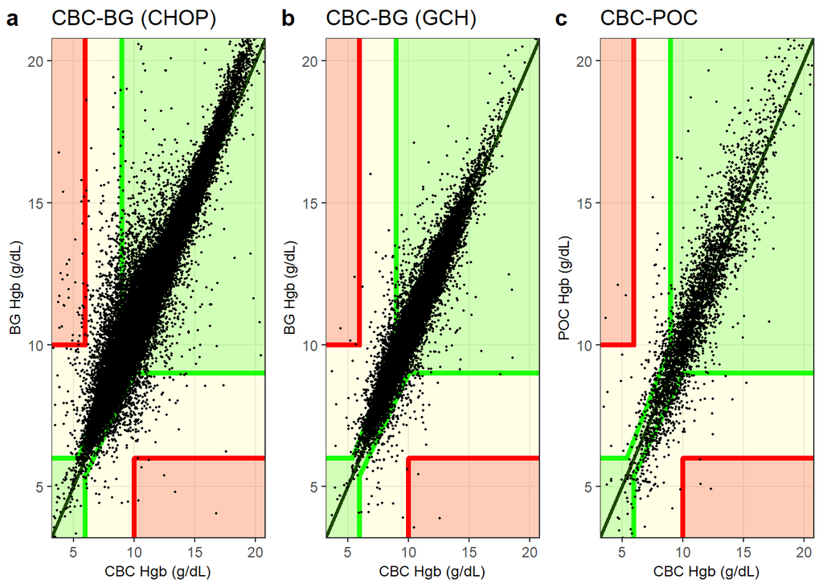

```r
# Export
ggplot2::ggsave(
  filename = file.path(
    Sys.getenv('PICU_LAB_IMG_PATH'),
    paste0(img.save.date, '_Supp-Figure-Orig-BA-Plots', ext)
  ),
  plot = Supp_BA_Plots,
  width = 4, height = 8, units = 'in', dpi = dpi, compression = compress)

Figure_2 <-
  cowplot::plot_grid(
    p.CHOP.EG.BG +
      ggtitle('CBC-BG (CHOP)') +
      xlab('CBC Hgb (g/dL)') +
      ylab('BG Hgb (g/dL)') +
      theme(
        title = element_text(size = 11),
        axis.title = element_text(size = 9)
      ),
    p.URMC.EG.BG +
      ggtitle('CBC-BG (GCH)') +
      xlab('CBC Hgb (g/dL)') +
      ylab('BG Hgb (g/dL)') +
      theme(
        title = element_text(size = 11),
        axis.title = element_text(size = 9)
      ),
    p.CHOP.EG.POC +
      ggtitle('CBC-POC') +
      xlab('CBC Hgb (g/dL)') +
      ylab('POC Hgb (g/dL)') +
      theme(
        title = element_text(size = 11),
        axis.title = element_text(size = 9)
      ),
    labels = tolower(LETTERS[1:3]),
    ncol = 3, nrow = 1)

print(Figure_2)
```

```r
# Export
ggplot2::ggsave(
  filename = file.path(
    Sys.getenv('PICU_LAB_IMG_PATH'),
    paste0(img.save.date, '_Figure-2', ext)
  ),
  plot = Figure_2,
  width = 8, height = 3, units = 'in', dpi = dpi, compression = compress)
```

### Figure 3

Figure 3 plots the NNM from the saved-out confusion matrices (see ~ line 939 in `03_Clinical_Accuracy.Rmd`). We load in the matrices, which are lists of lists.

```r
extractVar(mat.across.cutoffs, 'URMC.CUTOFFS', 'URMC', 'pri_cbc_bg_clinical', run.date)

extractVar(mat.across.cutoffs, 'CHOP.CUTOFFS', 'CHOP', 'pri_cbc_bg_clinical', run.date)
```

Now we create a smaller data frame, with just the FN and TN, to calculate the NPV or FOR.

```r
nnm.vals <- data.frame()

for (mat in CHOP.CUTOFFS) {

  nnm.vals <- rbind(
    nnm.vals,
    data.frame(
      fn = mat$res$FN,
      tn = mat$res$TN,
      cutoff = mat$cutoff,
      site = 'CHOP',
      src = 'BG'
    ), stringsAsFactors = F
  )

}

for (mat in URMC.CUTOFFS) {

  nnm.vals <- rbind(
    nnm.vals,
    data.frame(
      fn = mat$res$FN,
      tn = mat$res$TN,
      cutoff = mat$cutoff,
      site = 'GCH',
      src = 'BG'
    ), stringsAsFactors = F
  )

}
```

Combine the CHOP and URMC BG values into a combo column:

```r
nnm.vals.added <- nnm.vals

for (cut in unique(nnm.vals$cutoff)) {
  nnm.vals.added <-
    rbind(
      nnm.vals.added,
      data.frame(
        fn = nnm.vals$fn[nnm.vals$src == 'BG' & nnm.vals$site == 'CHOP' &
                           nnm.vals$cutoff == cut] +
          nnm.vals$fn[nnm.vals$src == 'BG' & nnm.vals$site == 'GCH' &
                        nnm.vals$cutoff == cut],
        tn = nnm.vals$tn[nnm.vals$src == 'BG' & nnm.vals$site == 'CHOP' &
                           nnm.vals$cutoff == cut] +
          nnm.vals$tn[nnm.vals$src == 'BG' & nnm.vals$site == 'GCH' &
                           nnm.vals$cutoff == cut],
        cutoff = cut,
        src = 'BG',
        site = 'Combined'
      ),
      stringsAsFactors = F
    )
}

nnm.vals.added <-
  nnm.vals.added %>%
  dplyr::mutate(
    false_or = fn / (tn + fn),
    nnm = 1. / false_or,
    site = factor(site),
    src = factor(src)
  )
```

Create the plot and save out:

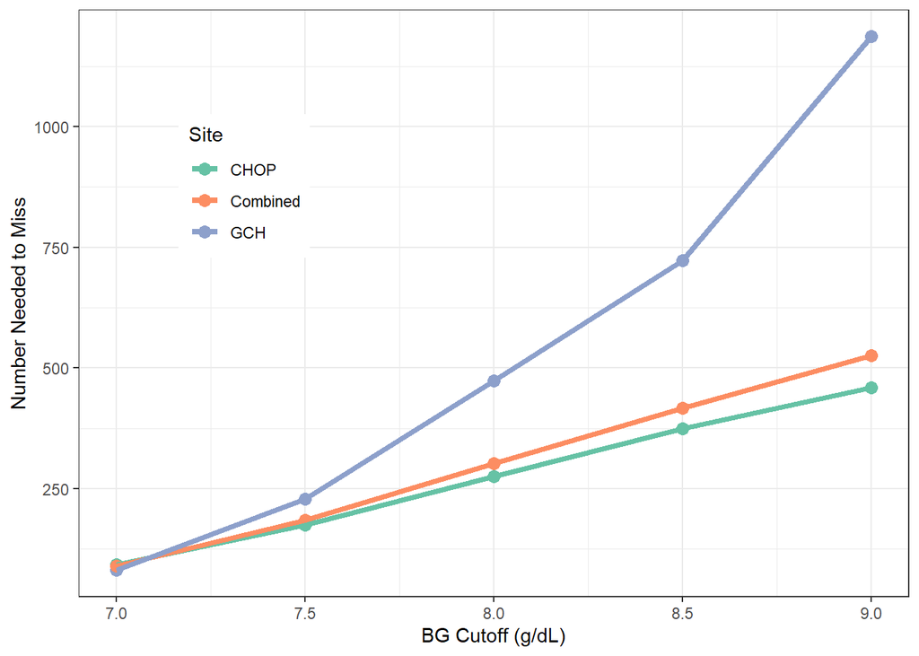

```r
Figure_3 <-
  nnm.vals.added %>%
  dplyr::filter(src == 'BG') %>%
  ggplot() +
  geom_point(aes(x = cutoff, y = nnm, color = site), size = 3) +
  geom_line(aes(x = cutoff, y = nnm, color = site), size = 1.5) +
  xlab('BG Cutoff (g/dL)') +
  ylab('Number Needed to Miss') +
  labs(color = 'Site') +
  scale_color_brewer(palette = 'Set2') +
  theme_bw() +
  theme(
    legend.position = c(0.2, 0.7)
  )

print(Figure_3)
```

```r
ggplot2::ggsave(
  filename = file.path(
    Sys.getenv('PICU_LAB_IMG_PATH'),
    paste0(img.save.date, '_Figure-3', ext)
  ),
  plot = Figure_3,
  width = 6, height = 4, units = 'in', dpi = dpi,
  compression = compress
)
```

### Figure 4

Figure 4 is a two-panel “Time To Result” plot. These are also found in `analytic` files.

```r
listVars('CHOP', 'pri_cbc_bg_analytic', run.date)
```

The variable of interest is `TTR.p`.

```r
extractVar(TTR.p, 'CHOP.TTR.BG', 'CHOP', 'pri_cbc_bg_analytic', run.date)

extractVar(TTR.p, 'URMC.TTR.BG', 'URMC', 'pri_cbc_bg_analytic', run.date)
```

And create the figure:

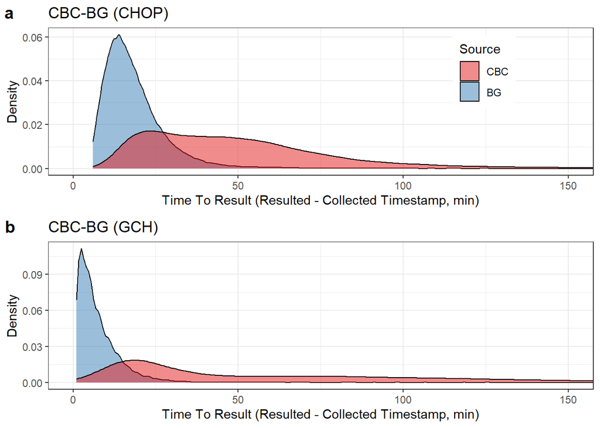

```r
Figure_4 <-
  cowplot::plot_grid(
    CHOP.TTR.BG$plot +
      ggtitle('CBC-BG (CHOP)') +
      theme(
        legend.position = c(0.8, 0.7)
      ),
    URMC.TTR.BG$plot +
      ggtitle('CBC-BG (GCH)') +
      theme(
        legend.position = 'none'
      ),
    labels = tolower(LETTERS[1:2]),
    ncol = 1, nrow = 2)

print(Figure_4)
```

```r
# Export
ggplot2::ggsave(
  filename = file.path(
    Sys.getenv('PICU_LAB_IMG_PATH'),
    paste0(img.save.date, '_Figure-4', ext)
  ),
  plot = Figure_4,
  width = 7, height = 7, units = 'in', dpi = dpi, compression = compress)
```

## Revision Figures

Here we plot figures necessary for manuscript revision. These figures will go in the supplementary data file, but because we are unsure about the numbers thus far, we will keep the un-numbered.

### Time Threshold

```r
listVars('CHOP', 'thresholds_cbc-bg', run.date)
```

The variable of interest is `p`.

```r
extractVar(p, 'CHOP.TimeThresh.BG', 'CHOP', 'thresholds_CBC-BG', run.date)

extractVar(p, 'CHOP.TimeThresh.POC', 'CHOP', 'thresholds_CBC-ISTAT', run.date)

extractVar(p, 'URMC.TimeThresh.BG', 'URMC', 'thresholds_CBC-BG', run.date)
```

And create the figure:

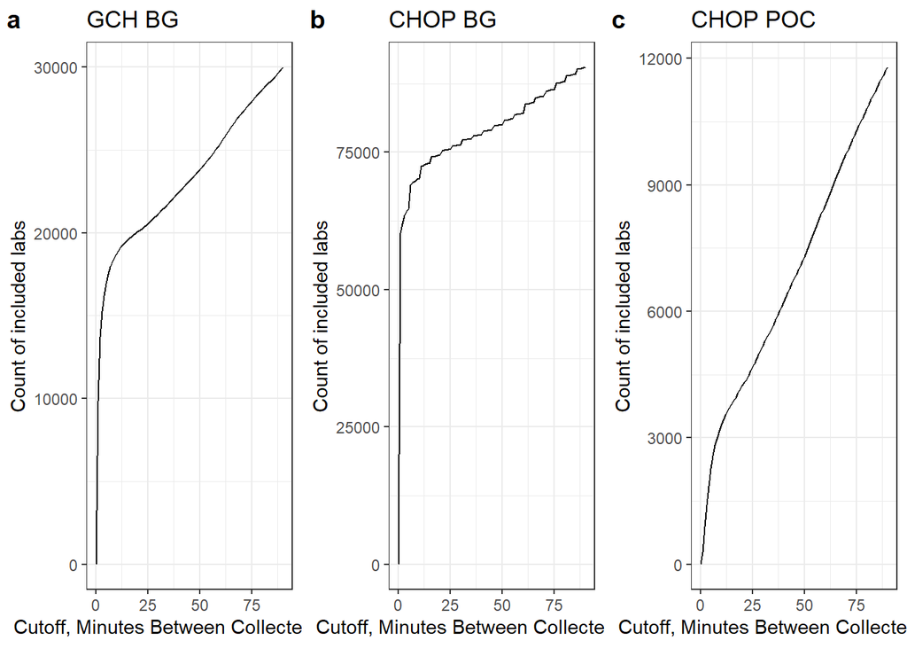

```r
Supp_Figure_TimeThresh <-
  cowplot::plot_grid(
    URMC.TimeThresh.BG +
      ggtitle('GCH BG') +
      theme(
        #axis.title.x = element_blank()
      ),
    CHOP.TimeThresh.BG +
      ggtitle('CHOP BG') +
      theme(
        #axis.title.x = element_blank()
      ),
    CHOP.TimeThresh.POC +
      ggtitle('CHOP POC') +
      theme(
        #legend.position = 'none'
      ),
    labels = tolower(LETTERS[1:3]),
    ncol = 3, nrow = 1)

print(Supp_Figure_TimeThresh)
```

```r
# Export
ggplot2::ggsave(
  filename = file.path(
    Sys.getenv('PICU_LAB_IMG_PATH'),
    paste0(img.save.date, '_Supp-Figure-TimeThreshold', ext)
  ),
  plot = Supp_Figure_TimeThresh,
  width = 12, height = 4, units = 'in', dpi = dpi, compression = compress)
```

### Bland Altman Non-Parameteric

We demonstrate the Q:Q plot for CBC-BG at both CHOP and URMC, along with the B-A plots for the non-parametric B-A (middle 95% of points). In that same section of the Supplemental Digital Content, we report the biases, LOA, and CIs for all of these measurements.

These figures are located in the `analytic` files.

```r
listVars('CHOP', 'pri_cbc_bg_analytic', run.date)
```

The variables of interest are `ba.all` and `ba.all.non.param`:

```r
extractVar(ba.all, 'CHOP.BA.BG', 'CHOP', 'pri_cbc_bg_analytic', run.date)

extractVar(ba.all, 'URMC.BA.BG', 'URMC', 'pri_cbc_bg_analytic', run.date)

extractVar(ba.all.non.param, 'CHOP.BA.NP.BG', 'CHOP', 'pri_cbc_bg_analytic', run.date)

extractVar(ba.all.non.param, 'URMC.BA.NP.BG', 'URMC', 'pri_cbc_bg_analytic', run.date)
```

We will create a 3 row x 2 col figure. The first row are original B-A QQ plots, second row are non-parametric B-A QQ plots, and third row are non-parametric B-A plots

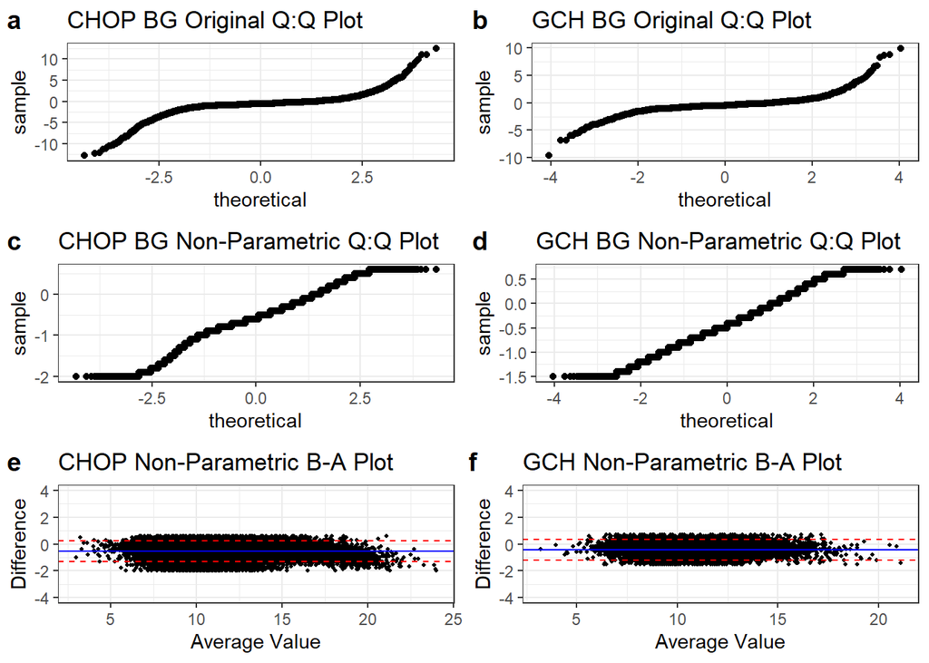

```r
Supp_Figure_NonParamBA <-
  cowplot::plot_grid(
    CHOP.BA.BG$qq.plot +
      ggtitle('CHOP BG Original Q:Q Plot') +
      theme(
        #axis.title.x = element_blank()
      ),
    URMC.BA.BG$qq.plot +
      ggtitle('GCH BG Original Q:Q Plot') +
      theme(
        #axis.title.x = element_blank()
      ),
    CHOP.BA.NP.BG$qq.plot +
      ggtitle('CHOP BG Non-Parametric Q:Q Plot') +
      theme(
        #axis.title.x = element_blank()
      ),
    URMC.BA.NP.BG$qq.plot +
      ggtitle('GCH BG Non-Parametric Q:Q Plot') +
      theme(
        #legend.position = 'none'
      ),
    CHOP.BA.NP.BG$plot +
      ylim(c(-4, 4)) +
      ggtitle('CHOP Non-Parametric B-A Plot') +
      theme(
        #axis.title.x = element_blank()
      ),
    URMC.BA.NP.BG$plot +
      ylim(c(-4, 4)) +
      ggtitle('GCH Non-Parametric B-A Plot') +
      theme(
        #axis.title.x = element_blank()
      ),
    labels = tolower(LETTERS[1:6]),
    ncol = 2, nrow = 3)

print(Supp_Figure_NonParamBA)
```

```r
# Export
ggplot2::ggsave(
  filename = file.path(
    Sys.getenv('PICU_LAB_IMG_PATH'),
    paste0(img.save.date, '_Supp-Figure-NonParam-BA', ext)
  ),
  plot = Supp_Figure_NonParamBA,
  width = 8, height = 10, units = 'in', dpi = dpi, compression = compress)
```

### Temporal Analysis

Here we plot the Temporal 4-quadrant plots, for both All Pairs and a restricted subset of pairs.

```r
listVars('URMC', 'pri_cbc_bg_temporal', run.date)
```

The variables of interest are `cbc.bg.all.pairs` and `cbc.bg.restrict.pairs`:

```r
extractVar(cbc.bg.all.pairs, 'CHOP.ALL', 'CHOP', 'pri_cbc_bg_temporal', run.date)

extractVar(cbc.bg.all.pairs, 'URMC.ALL', 'URMC', 'pri_cbc_bg_temporal', run.date)

extractVar(cbc.bg.restrict.pairs, 'CHOP.RESTRICT', 'CHOP', 'pri_cbc_bg_temporal', run.date)

extractVar(cbc.bg.restrict.pairs, 'URMC.RESTRICT', 'URMC', 'pri_cbc_bg_temporal', run.date)
```

Now we create the supplementary figure, which will be 2row x 2 cols. The top row will include all points, and the bottom row will restrict to those <= 6 hrs of initial labs.

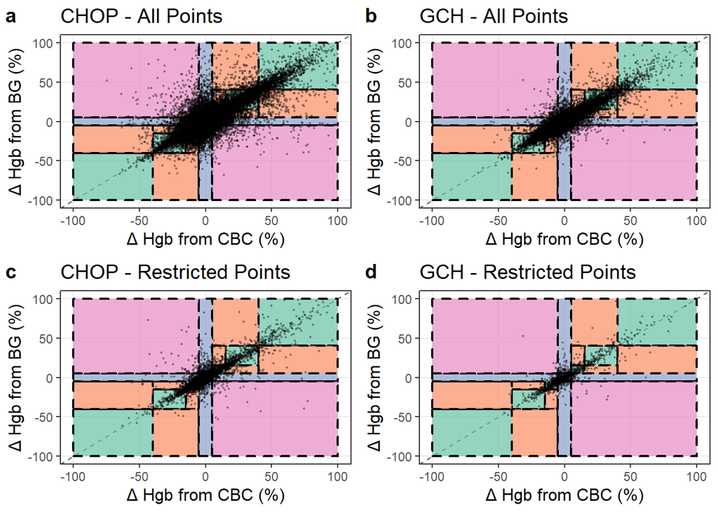

```r
Supp_Figure_Temporal_4q <-
  cowplot::plot_grid(
    CHOP.ALL[[1]] +
      ggtitle('CHOP - All Points') +
      theme(
        title = element_text(size = 12)
        #axis.title.x = element_blank()
      ),
    URMC.ALL[[1]] +
      ggtitle('GCH - All Points') +
      theme(
        title = element_text(size = 12)
        #axis.title.x = element_blank()
      ),
    CHOP.RESTRICT[[1]] +
      ggtitle('CHOP - Restricted Points') +
      theme(
        title = element_text(size = 12)
        #axis.title.x = element_blank()
      ),
    URMC.RESTRICT[[1]] +
      ggtitle('GCH - Restricted Points') +
      theme(
        title = element_text(size = 12)
        #axis.title.x = element_blank()
      ),
    labels = tolower(LETTERS[1:4]),
    ncol = 2, nrow = 2)
print(Supp_Figure_Temporal_4q)
```

```r
# Export
ggplot2::ggsave(
  filename = file.path(
    Sys.getenv('PICU_LAB_IMG_PATH'),
    paste0(img.save.date, '_Supp-Figure-Temporal-4Q', ext)
  ),
  plot = Supp_Figure_Temporal_4q,
  width = 8, height = 8, units = 'in', dpi = dpi, compression = compress)
```

```r
rm(CHOP.ALL, URMC.ALL, CHOP.RESTRICT, URMC.RESTRICT)
rm(Supp_Figure_Temporal_4q)
```

### Test ROC and PR Curves

Here we plot the ROC and P-R curves for the BG and POC calculations, for CHOP and URMC.

The variables of interest are `cbc.bg.thresh.roc` and `thresh.roc`:

```r
extractVar(cbc.bg.thresh.roc, 'CHOP.BG', 'CHOP', 'pri_cbc_bg_clinical', run.date)

extractVar(thresh.roc, 'CHOP.POC', 'CHOP', 'pri_cbc_istat_clinical', run.date)

extractVar(cbc.bg.thresh.roc, 'URMC.BG', 'URMC', 'pri_cbc_bg_clinical', run.date)
```

Now we create the supplementary figure, which will 3 rows x 2 cols. Col 1 is ROC, Col 2 is P-R. Row 1 is CHOP BG, row 2 is CHOP POC, row 3 is URMC BG.

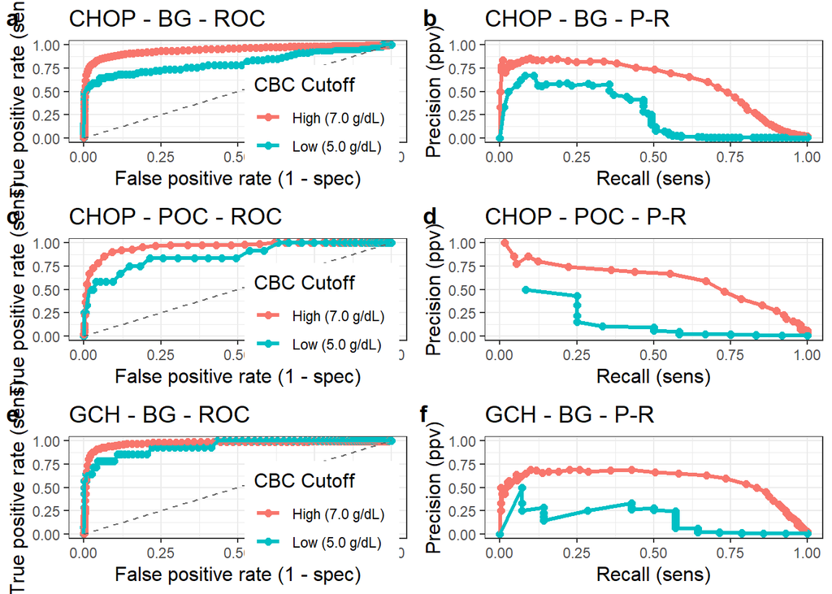

```r
Supp_Figure_Thresh_Curves <-
  cowplot::plot_grid(
    CHOP.BG$p.roc +
      ggtitle('CHOP - BG - ROC') +
      theme(
        title = element_text(size = 12),
        legend.position = c(0.75, 0.25)
        #axis.title.x = element_blank()
      ),
    CHOP.BG$p.pr +
      ggtitle('CHOP - BG - P-R') +
      theme(
        title = element_text(size = 12),
        legend.position = 'none'
        #axis.title.x = element_blank()
      ),
    CHOP.POC$p.roc +
      ggtitle('CHOP - POC - ROC') +
      theme(
        title = element_text(size = 12),
        legend.position = c(0.75, 0.25)
        #axis.title.x = element_blank()
      ),
    CHOP.POC$p.pr +
      ggtitle('CHOP - POC - P-R') +
      theme(
        title = element_text(size = 12),
        legend.position = 'none'
        #axis.title.x = element_blank()
      ),
    URMC.BG$p.roc +
      ggtitle('GCH - BG - ROC') +
      theme(
        title = element_text(size = 12),
        legend.position = c(0.75, 0.25)
        #axis.title.x = element_blank()
      ),
    URMC.BG$p.pr +
      ggtitle('GCH - BG - P-R') +
      theme(
        title = element_text(size = 12),
        legend.position = 'none'
        #axis.title.x = element_blank()
      ),
    labels = tolower(LETTERS[1:6]),
    ncol = 2, nrow = 3)
print(Supp_Figure_Thresh_Curves)
```

```r
# Export
ggplot2::ggsave(
  filename = file.path(
    Sys.getenv('PICU_LAB_IMG_PATH'),
    paste0(img.save.date, '_Supp-Figure-Thresh-Curves', ext)
  ),
  plot = Supp_Figure_Thresh_Curves,
  width = 7, height = 10, units = 'in', dpi = dpi, compression = compress)
```

```r
rm(CHOP.BG, CHOP.POC, URMC.BG)
rm(Supp_Figure_Thresh_Curves)
```